# Consumo de Cerveja

Alex de Sousa Pereira

21/04/2021

(esse material foi 100% produzido usando a linguagem R)

###OBJETIVO DO TRABALHO

Este trabalho tem como objetivo explorar dados do consumo de cerveja usando a biblioteca Rmarkdown, por meio de:

- Importação dos dados;
- Análise descritiva dos dados;
- Gráficos.

### 1 - BIBLIOTECAS UTILIZADAS

As bibliotecas que utilizaremos para este trabalho encontram-se abaixo:

```r
# Carregando os pacotes
library(ggplot2) # Criação de gráficos
library(dplyr) # Manipulação de dados
library(stringr) # manipulação de strings
library(lubridate) # manipulação de datas
library(ggcorrplot) # criação do gráfico de correlação
```

### 2 - CARREGANDO OS DADOS

O arquivo dos nossos dados corresponde a um arquivo csv. Para lermos este arquivo, utilizaremos a funçao “read_csv” que já é vinculada ao R.

```r
options(knitr.duplicate.label = "allow")
df = read.csv("https://raw.githubusercontent.com/alexdesousapereira/Analise-do-Consumo-de-Bebida-Alcoolica/main/Dados/consumo_cerveja.csv",sep = ";")
dim(df)
```

```
## [1] 365   7
```

```r
head(df)
```

```
##         Data Temperatura.Media..C. Temperatura.Minima..C.
## 1 01/01/2019                  27,3                   23,9
## 2 02/01/2019                 27,02                   24,5
## 3 03/01/2019                 24,82                   22,4
## 4 04/01/2019                 23,98                   21,5
## 5 05/01/2019                 23,82                     21
## 6 06/01/2019                 23,78                   20,1
##   Temperatura.Maxima..C. Precipitacao..mm. Final.de.Semana
## 1                   32,5                 0               0
## 2                   33,5                 0               0
## 3                   29,9                 0               1
## 4                   28,6               1,2               1
## 5                   28,3                 0               0
## 6                   30,5              12,2               0
##   Consumo.de.cerveja..litros.
## 1                       25461
## 2                       28972
## 3                       30814
## 4                       29799
## 5                       28900
## 6                       28218
```

### 3 - DESCRIÇÃO DAS COLUNAS

Descrevendo as colunas:

Data: dia que foram coletados os dados.

Temperatura média (C): temperatura média para o respectivo dia.

Temperatura mínima (C): temperatura mínima para o respectivo dia.

Temperatura máxima (C): temperatura máxima para o respectivo dia.

Precipitação (mm): quantidade em mililitros de chuva para o respectivo dia.

Final de Semana: se o respectivo dia era final de semana.

(1=sim, 0=não).

Consumo de cerveja (litros): consumo de cerveja em litros para o respectivo dia.

Observando o resultado acima, verificamos a quantidade total de registros com 365 linhas e 7 colunas.

### 4 - LIMPEZA E TRANSFORMAÇÃO DAS VARIÁVEIS

Primeiramente iremos analisar o tipo de nossas variáveis.

```r
str(df)
```

```
## 'data.frame':    365 obs. of  7 variables:
##  $ Data                       : chr  "01/01/2019" "02/01/2019" "03/01/2019" "04/01/2019" ...
##  $ Temperatura.Media..C.      : chr  "27,3" "27,02" "24,82" "23,98" ...
##  $ Temperatura.Minima..C.     : chr  "23,9" "24,5" "22,4" "21,5" ...
##  $ Temperatura.Maxima..C.     : chr  "32,5" "33,5" "29,9" "28,6" ...
##  $ Precipitacao..mm.          : chr  "0" "0" "0" "1,2" ...
##  $ Final.de.Semana            : int  0 0 1 1 0 0 0 0 0 1 ...
##  $ Consumo.de.cerveja..litros.: int  25461 28972 30814 29799 28900 28218 29732 28397 24886 37937 ...
```

Logo, verificamos que algumas variáveis estão em formato caractere. Então, iremos fazer a transformarção destas variáveis.

```r
df$Temperatura.Maxima..C. =  df$Temperatura.Maxima..C. %>% str_replace('[,]', '.')%>% as.double()
df$Temperatura.Media..C. = df$Temperatura.Media..C. %>% str_replace('[,]', '.') %>% as.double()
df$Temperatura.Minima..C. = df$Temperatura.Minima..C. %>% str_replace('[,]', '.') %>% as.double()
df$Precipitacao..mm. = df$Precipitacao..mm. %>% str_replace('[,]', '.') %>% as.double()
```

Feito a transformação destas colunas, iremos verificar a presença de valores nulos em nosso dataset.

```r
df[!complete.cases(df),] # Verifica valores nullos no dataset
```

```
##           Data Temperatura.Media..C. Temperatura.Minima..C.
## 78  19/03/2019                    NA                   19.2
## 191 10/07/2019                 19.24                   14.0
## 254 11/09/2019                 16.88                     NA
##     Temperatura.Maxima..C. Precipitacao..mm. Final.de.Semana
## 78                    27.1               3.2               0
## 191                     NA               0.0               0
## 254                   21.8              31.8               0
##     Consumo.de.cerveja..litros.
## 78                        23628
## 191                       25698
## 254                       21454
```

Como os valores que estão em nossas colunas podem ser relevantes para nossa análise, não iremos remover as linhas que contêm valores nullos.

Então, iremos substituir estes valores pela mediana de cada variável que se encontra com valor nulo. Outras soluções possiveís, seriam utilizar-mos a média, ou um modelo de machine learning para tentar prever esses valores para cada variável.

```r
df[is.na(df$Temperatura.Maxima..C.),]$Temperatura.Maxima..C. = median(df$Temperatura.Maxima..C.,na.rm = T)
df[is.na(df$Temperatura.Minima..C.),]$Temperatura.Minima..C. = median(df$Temperatura.Minima..C.,na.rm = T)
df[is.na(df$Temperatura.Media..C.),]$Temperatura.Media..C. = median(df$Temperatura.Media..C.,na.rm = T)
df[!complete.cases(df),] # Verificando se ainda existem valores nullos no dataset
```

```
## [1] Data                        Temperatura.Media..C.
## [3] Temperatura.Minima..C.      Temperatura.Maxima..C.
## [5] Precipitacao..mm.           Final.de.Semana
## [7] Consumo.de.cerveja..litros.
## <0 rows> (or 0-length row.names)
```

Agora, iremos fazer uma transformação afim de facilitar em nossa análise de dados. Para tanto, iremos transformar a coluna “Final de Semana”, em que:

0 = “Dia da Semana”;

1 = “Final de Semana”.

```r
#Convertendo coluna Final de Semana
# Vamos Converter algumas variáveis agora
df$Final.de.Semana = cut(df$Final.de.Semana,
                         c(-1,0,1),
                         labels = c("Dia de Semana","Fim de Semana"))
```

### CRIANDO COLUNA DIA E MÊS

Utilizare-mos o pacote “lubridate”, afim de criar uma coluna dia da semana e uma coluna mês para ajudar na análise dos dados.

```r
# Criando coluna Dia da Semana
df$Dia.da.Semana = c(seq(1:length(df$Data)))
for (i in 1:length(df$Dia.da.Semana)){
  df$Dia.da.Semana[i] = wday(df$Data[i])
}
df$Dia.da.Semana= cut(df$Dia.da.Semana,
                         c(0,1,2,3,4,5,6,7),
                         labels = c("Domingo",
                                    "Segunda",
                                    "Terça",
                                    "Quarta",
                                    "Quinta",
                                    "Sexta",
                                    "Sábado"))
# Criando coluna Mês
df$Mes = c(seq(1:length(df$Data)))
for (i in 1:length(df$Data)){
  df$Mes[i] = month(df$Data[i])
}
df$Mes= cut(df$Mes,
              c(0,1,2,3,4,5,6,7,8,9,10,11,12),
              labels = c("Janeiro",
                         "Fevereiro",
                         "Março",
                         "Abril",
                         "Maio",
                         "Junho",
                         "Julho",
                         "Agosto",
                         "Setembro",
                         "Outubro",
                         "Novembro",
                         "Dezembro"))
```

### ANÁLISE DOS DADOS

Nesta parte, iremos analisar nossos dados graficamente afim de chegar a possivéis conclusões.

#### Análise de Correlação

Nesta etapa, iremos analisar quais variáveis são mais correlacionadas com o consumo de cerveja.

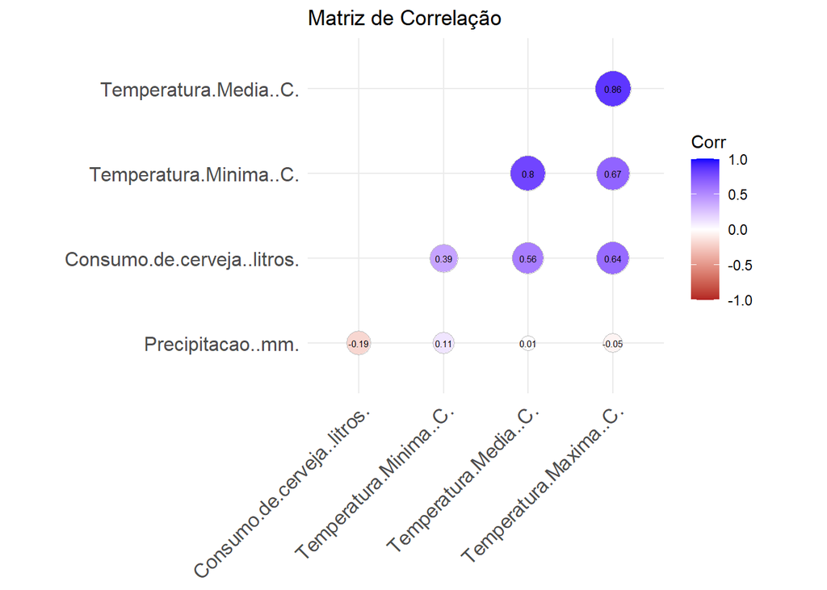

```r
df_corr = select_if(df,is.numeric) %>% cor() %>% round(2)
ggcorrplot(df_corr,type = "lower", # Retira o espelho da matriz
           hc.order = T, # organiza os valores
           method = "circle", # formato dos componentes da matriz
           lab = TRUE, # adicionar os valores das correlações
           lab_size = 2,# Tamamho dos Valores
           colors = c("firebrick", "white","blue"), # cores do gráfico
           title = "Matriz de Correlação"
           )
```

Analisando o gráfico de correlação, pode-se observar que existe uma correlação negativa de ‘consumo’ com “precipitação”,ou seja,a medida que chove mais o consumo de cerveja diminui.

Pode-se observar também, que existe uma correlação positiva de “consumo” com “temperatura máxima”, ou seja, quanto maior a temperatura, maior será o consumo de cerveja.

####CONSUMO DE CERVEJA POR DIA DA SEMANA

Este tópico tem como objetivo analisar o consumo de bebida alcoólica por dia da semana.

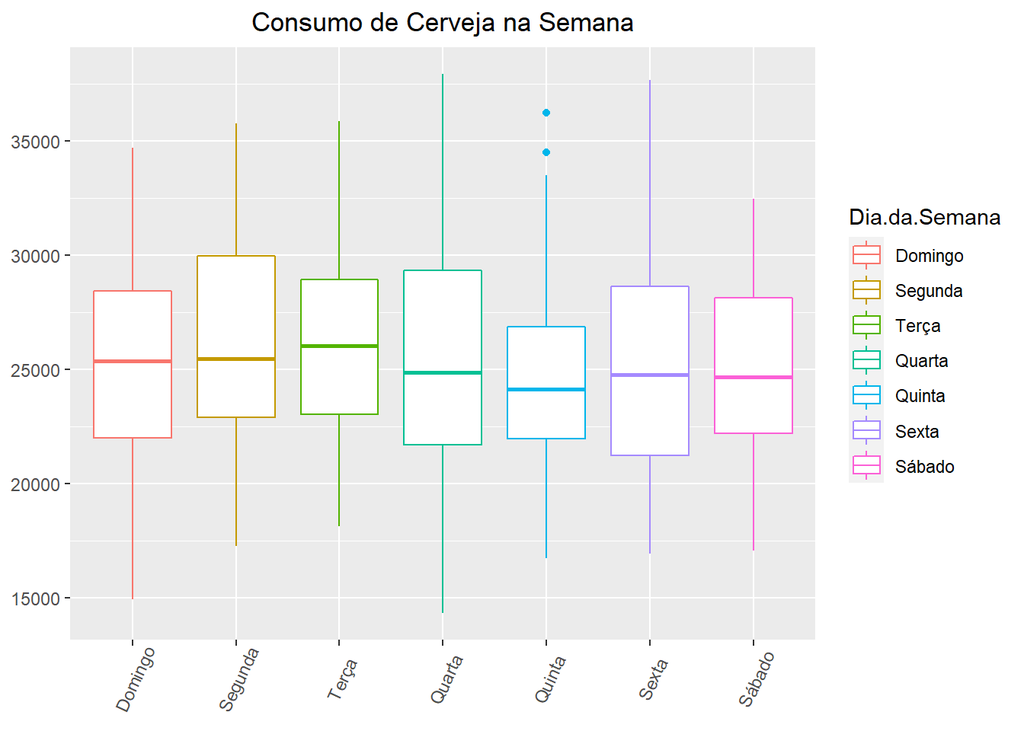

```r
ggplot(df) +
  aes(x = Dia.da.Semana,y = Consumo.de.cerveja..litros.,col = Dia.da.Semana) +
  labs(x = "Dia da Semana",
       y = "Consumo de Cerveja",
       title = "Consumo de Cerveja na Semana") +
  theme(axis.text.x = element_text(angle=65, vjust=0.6),
        # Centralizar o título
        plot.title = element_text(hjust = 0.5),
        #Tirar o título do eixo x
        axis.title.x=element_blank(),
        #Tirar o título do eixo y
        axis.title.y=element_blank()) +
  geom_boxplot()
```

#### CONSUMO DE CERVEJA NO MÊS

Este tópico tem como objetivo analisar o consumo de bebida alcoólica por mês.

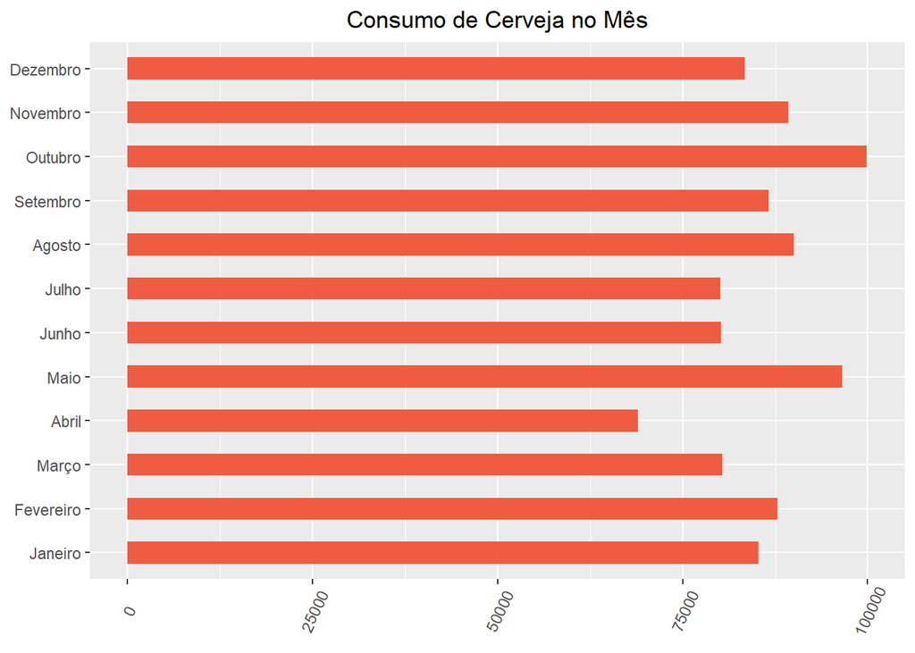

```r
# Consumo de Cerveja por mês

ggplot(df) +
  aes(x = Mes,y = Consumo.de.cerveja..litros.) +
  labs(x = "Mês",
       y = "Consumo de Cerveja",
       title = "Consumo de Cerveja no Mês") +
  geom_col(stat="identity", width = 0.5, fill="tomato2") +
  theme(axis.text.x = element_text(angle=65, vjust=0.6),
        # Centralizar o título
        plot.title = element_text(hjust = 0.5),
        #Tirar o título do eixo x
        axis.title.x=element_blank(),
        #Tirar o título do eixo y
        axis.title.y=element_blank()) +
  ylim(limits= c(0,100000)) +
  coord_flip()
```

#### CONSUMO MÉDIO DE CERVEJA NO FINAL DE SEMANA

Este tópico têm como principal objetivo analisar o consumo de cerveja nos finais de semana.

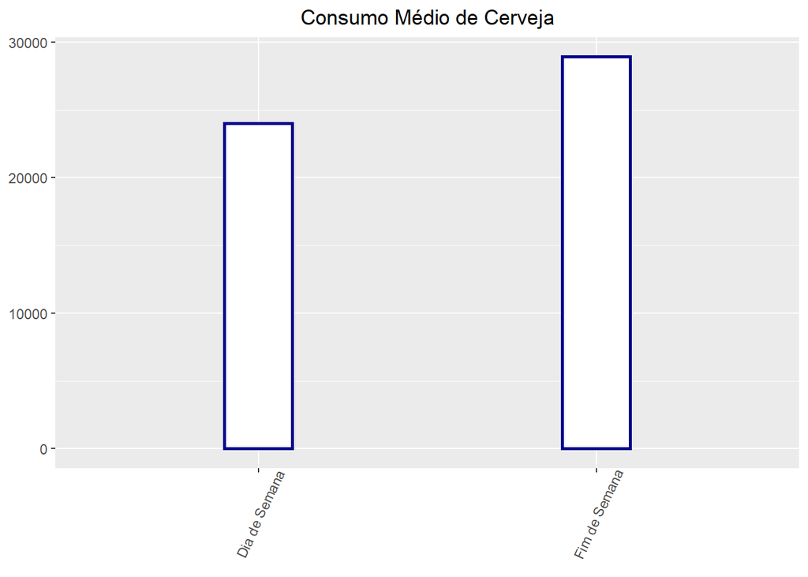

```r
# Consumo médio de cerveja no Dia de Semana e no Final de Semana
X = group_by(df,Final.de.Semana)%>%summarise(Total=mean(Consumo.de.cerveja..litros.))
ggplot(X) +
  aes(x =Final.de.Semana ,y = Total) +
  labs(title = "Consumo Médio de Cerveja") +
  geom_col(width= 0.2,size = 1,color="darkblue",fill="white") +
  theme(axis.text.x = element_text(angle=65, vjust=0.6),
        #Centralizar o título
        plot.title = element_text(hjust = 0.5),
        #Tirar o título do eixo x
        axis.title.x=element_blank(),
        # Tirar o título do eixo y
        axis.title.y=element_blank()
  )
```

Analisando, pode-se observar que temos um consumo maior de cerveja nos fins de semana do que nos dias de semana.